# TSK_INN_Learner_Notebook_Full_code

Bank Churn Prediction

## Problem Statement

### Context

Businesses like banks which provide service have to worry about problem of 'Customer Churn' i.e. customers leaving and joining another service provider. It is important to understand which aspects of the service influence a customer's decision in this regard. Management can concentrate efforts on improvement of service, keeping in mind these priorities.

### Objective

You as a Data scientist with the bank need to build a neural network based classifier that can determine whether a customer will leave the bank or not in the next 6 months.

### Data Dictionary

- CustomerId: Unique ID which is assigned to each customer
- Surname: Last name of the customer
- CreditScore: It defines the credit history of the customer.
- Geography: A customer’s location
- Gender: It defines the Gender of the customer
- Age: Age of the customer
- Tenure: Number of years for which the customer has been with the bank
- NumOfProducts: refers to the number of products that a customer has purchased through the bank.
- Balance: Account balance
- HasCrCard: It is a categorical variable which decides whether the customer has credit card or not.
- EstimatedSalary: Estimated salary
- isActiveMember: Is is a categorical variable which decides whether the customer is active member of the bank or not ( Active member in the sense, using bank products regularly, making transactions etc )
- Exited : whether or not the customer left the bank within six month. It can take two values ** 0=No ( Customer did not leave the bank ) ** 1=Yes ( Customer left the bank )

## Importing necessary libraries

```python
# Installing the libraries with the specified version.
# uncomment and run the following line if Google Colab is being used
!pip install scikit-learn==1.3.2 seaborn==0.13.1 matplotlib==3.8.0 numpy==1.26.4 pandas==2.2.2 imbalanced-learn==0.13.0 xgboost==1.6.2 -q --user --no-warn-script-location
```

```python
# Installing the libraries with the specified version.
# uncomment and run the following lines if Jupyter Notebook is being used
# !pip install scikit-learn==1.3.2 seaborn==0.13.1 matplotlib==3.8.0 numpy==1.26.0 pandas==2.2.2 imblearn==0.13.0 xgboost==1.6.2 -q --user --no-warn-script-location
#!pip install --upgrade -q threadpoolctl
```

**Note**: *After running the above cell, kindly restart the notebook kernel and run all cells sequentially from the start again*.

```python
# Libraries to help with reading and manipulating data
import numpy as np
import pandas as pd
import time

# Libraries to help with data visualization
import matplotlib.pyplot as plt
import seaborn as sns

# to compute classification metrics
from sklearn import metrics
from sklearn.metrics import (
    classification_report,
    confusion_matrix,
    accuracy_score,
    recall_score,
    precision_score,
    f1_score,
)

# To oversample the data
from imblearn.over_sampling import SMOTE

# to split data into training and test sets
from sklearn.model_selection import train_test_split
from sklearn.preprocessing import StandardScaler

import tensorflow as tf #An end-to-end open source machine learning platform
from tensorflow import keras  # High-level neural networks API for deep learning.
from keras import backend   # Abstraction layer for neural network backend engines.
from keras.models import Sequential  # Model for building NN sequentially.
from keras.layers import Dense,Dropout

import warnings
warnings.filterwarnings('ignore')
```

```python
# Set the seed using keras.utils.set_random_seed. This will set:
# 1) `numpy` seed
# 2) backend random seed
# 3) `python` random seed
keras.utils.set_random_seed(812)
```

## Loading the dataset

```python
from google.colab import drive
drive.mount('/content/drive')
```

```python
# Read the data from the csv file
bankdata = pd.read_csv('/content/drive/MyDrive/Introduction to Neural Networks/Bank Churn Prediction/bank-1.csv')
```

```python
# Read the data from the csv file
#bankdata = pd.read_csv('bank-1.csv')
```

```python
# Copy the bank data for further processing to avoid any changes to the original data
data = bankdata.copy()
```

## Data Overview

### Viewing the first five and last five records of the data

```python
# Code to look at the first 5 rows
data.head(5)
```

|  | RowNumber | CustomerId | Surname | CreditScore | Geography | Gender | Age | Tenure | Balance | NumOfProducts | HasCrCard | IsActiveMember | EstimatedSalary | Exited |
| --- | --- | --- | --- | --- | --- | --- | --- | --- | --- | --- | --- | --- | --- | --- |
| 0 | 1 | 15634602 | Hargrave | 619 | France | Female | 42 | 2 | 0.00 | 1 | 1 | 1 | 101348.88 | 1 |
| 1 | 2 | 15647311 | Hill | 608 | Spain | Female | 41 | 1 | 83807.86 | 1 | 0 | 1 | 112542.58 | 0 |
| 2 | 3 | 15619304 | Onio | 502 | France | Female | 42 | 8 | 159660.80 | 3 | 1 | 0 | 113931.57 | 1 |
| 3 | 4 | 15701354 | Boni | 699 | France | Female | 39 | 1 | 0.00 | 2 | 0 | 0 | 93826.63 | 0 |
| 4 | 5 | 15737888 | Mitchell | 850 | Spain | Female | 43 | 2 | 125510.82 | 1 | 1 | 1 | 79084.10 | 0 |

```python
# Code to look at the last 5 rows
data.tail(5)
```

|  | RowNumber | CustomerId | Surname | CreditScore | Geography | Gender | Age | Tenure | Balance | NumOfProducts | HasCrCard | IsActiveMember | EstimatedSalary | Exited |
| --- | --- | --- | --- | --- | --- | --- | --- | --- | --- | --- | --- | --- | --- | --- |
| 9995 | 9996 | 15606229 | Obijiaku | 771 | France | Male | 39 | 5 | 0.00 | 2 | 1 | 0 | 96270.64 | 0 |
| 9996 | 9997 | 15569892 | Johnstone | 516 | France | Male | 35 | 10 | 57369.61 | 1 | 1 | 1 | 101699.77 | 0 |
| 9997 | 9998 | 15584532 | Liu | 709 | France | Female | 36 | 7 | 0.00 | 1 | 0 | 1 | 42085.58 | 1 |
| 9998 | 9999 | 15682355 | Sabbatini | 772 | Germany | Male | 42 | 3 | 75075.31 | 2 | 1 | 0 | 92888.52 | 1 |
| 9999 | 10000 | 15628319 | Walker | 792 | France | Female | 28 | 4 | 130142.79 | 1 | 1 | 0 | 38190.78 | 0 |

### Checking the shape of the data

```python
data.shape
```

```
(10000, 14)
```

- There are 10000 rows and 14 columns

### Checking the attribute types

```python
# Check the data type of the columns
data.info()
```

```
<class 'pandas.core.frame.DataFrame'>
RangeIndex: 10000 entries, 0 to 9999
Data columns (total 14 columns):
 #   Column           Non-Null Count  Dtype
---  ------           --------------  -----
 0   RowNumber        10000 non-null  int64
 1   CustomerId       10000 non-null  int64
 2   Surname          10000 non-null  object
 3   CreditScore      10000 non-null  int64
 4   Geography        10000 non-null  object
 5   Gender           10000 non-null  object
 6   Age              10000 non-null  int64
 7   Tenure           10000 non-null  int64
 8   Balance          10000 non-null  float64
 9   NumOfProducts    10000 non-null  int64
 10  HasCrCard        10000 non-null  int64
 11  IsActiveMember   10000 non-null  int64
 12  EstimatedSalary  10000 non-null  float64
 13  Exited           10000 non-null  int64
dtypes: float64(2), int64(9), object(3)
memory usage: 1.1+ MB
```

- There are 11 numeric and 3 categorical columns in the data.
- `RowNumber` column though interpreted as numerical, it's a categorical variable representing the unique value of the record.
- `CustomerId` column though interpreted as numerical, it's a categorical variable representing the unique value of the customers.

### Fixing the data types

```python
#convert 'RowNumber' and 'CustomerId' columns to categorical features
data['RowNumber'] = data['RowNumber'].astype('category')
data['CustomerId'] = data['CustomerId'].astype('category')
```

```python
#convert all object features to category type
for col in data.select_dtypes('object').columns:
    data[col] = data[col].astype('category')
```

### Checking the statistical summary

```python
# Check the statistical summary for numerical features
data.describe().T
```

|  | count | mean | std | min | 25% | 50% | 75% | max |
| --- | --- | --- | --- | --- | --- | --- | --- | --- |
| CreditScore | 10000.0 | 650.528800 | 96.653299 | 350.00 | 584.00 | 652.000 | 718.0000 | 850.00 |
| Age | 10000.0 | 38.921800 | 10.487806 | 18.00 | 32.00 | 37.000 | 44.0000 | 92.00 |
| Tenure | 10000.0 | 5.012800 | 2.892174 | 0.00 | 3.00 | 5.000 | 7.0000 | 10.00 |
| Balance | 10000.0 | 76485.889288 | 62397.405202 | 0.00 | 0.00 | 97198.540 | 127644.2400 | 250898.09 |
| NumOfProducts | 10000.0 | 1.530200 | 0.581654 | 1.00 | 1.00 | 1.000 | 2.0000 | 4.00 |
| HasCrCard | 10000.0 | 0.705500 | 0.455840 | 0.00 | 0.00 | 1.000 | 1.0000 | 1.00 |
| IsActiveMember | 10000.0 | 0.515100 | 0.499797 | 0.00 | 0.00 | 1.000 | 1.0000 | 1.00 |
| EstimatedSalary | 10000.0 | 100090.239881 | 57510.492818 | 11.58 | 51002.11 | 100193.915 | 149388.2475 | 199992.48 |
| Exited | 10000.0 | 0.203700 | 0.402769 | 0.00 | 0.00 | 0.000 | 0.0000 | 1.00 |

```python
# Check the statistical summary for categorical features
data.describe(include = ['object','category']).T
```

|  | count | unique | top | freq |
| --- | --- | --- | --- | --- |
| RowNumber | 10000 | 10000 | 1 | 1 |
| CustomerId | 10000 | 10000 | 15565701 | 1 |
| Surname | 10000 | 2932 | Smith | 32 |
| Geography | 10000 | 3 | France | 5014 |
| Gender | 10000 | 2 | Male | 5457 |

- `RowNumber` is unique and can be dropped.
- `CustomerId` is unique for each customer and can be dropped.
- There are 2932 unique `Surname`, indicating some surnames are shared."Smith" is the most frequent surname, shared by 32 customers.
- `Geography` Customers are distributed between three distinct locations, with "France" being the most frequent (5014 occurrences).
- `Gender` Male and Female customers are in the dataset, with "Male" being more frequent (5457 occurrences).

**Dropping columns which are not adding any information.**

```python
# Drop columns with unique data
data.drop(['RowNumber','CustomerId'],axis=1,inplace=True)
```

```python
# Drop the Surname feature as this is PII data. It would also have high cardinality and might inroduce bias.
data.drop('Surname',axis=1,inplace=True)
```

**Let's look at the unique values of all the categories**

```python
for col in data.select_dtypes('category').columns:
    print('Unique values in',col, 'are :')
    print(data[col].value_counts())
    print('*'*50)
```

```
Unique values in Geography are :
Geography
France     5014
Germany    2509
Spain      2477
Name: count, dtype: int64
Unique values in Gender are :
Gender
Male      5457
Female    4543
Name: count, dtype: int64
```

### Checking for missing values

```python
data.isnull().sum()
```

|  | 0 |
| --- | --- |
| CreditScore | 0 |
| Geography | 0 |
| Gender | 0 |
| Age | 0 |
| Tenure | 0 |
| Balance | 0 |
| NumOfProducts | 0 |
| HasCrCard | 0 |
| IsActiveMember | 0 |
| EstimatedSalary | 0 |
| Exited | 0 |

**dtype:** int64

- There are no missing values.

### Checking for duplicate values

```python
data.duplicated().sum()
```

```
0
```

- There are no duplicate values in the data.

## Exploratory Data Analysis

### Utility Functions

**The below functions need to be defined to carry out the EDA.**

```python
def histogram_boxplot(data, feature, figsize=(15, 10), kde=False, bins=None):
    """
    Boxplot and histogram combined

    data: dataframe
    feature: dataframe column
    figsize: size of figure (default (15,10))
    kde: whether to show the density curve (default False)
    bins: number of bins for histogram (default None)
    """
    f2, (ax_box2, ax_hist2) = plt.subplots(
        nrows=2,  # Number of rows of the subplot grid= 2
        sharex=True,  # x-axis will be shared among all subplots
        gridspec_kw={"height_ratios": (0.25, 0.75)},
        figsize=figsize,
    )  # creating the 2 subplots
    sns.boxplot(
        data=data, x=feature, ax=ax_box2, showmeans=True, color="violet"
    )  # boxplot will be created and a triangle will indicate the mean value of the column
    sns.histplot(
        data=data, x=feature, kde=kde, ax=ax_hist2, bins=bins
    ) if bins else sns.histplot(
        data=data, x=feature, kde=kde, ax=ax_hist2
    )  # For histogram
    ax_hist2.axvline(
        data[feature].mean(), color="green", linestyle="--"
    )  # Add mean to the histogram
    ax_hist2.axvline(
        data[feature].median(), color="black", linestyle="-"
    )  # Add median to the histogram
```

```python
# function to create labeled barplots
def labeled_barplot(data, feature, perc=False, n=None):
    """
    Barplot with percentage at the top

    data: dataframe
    feature: dataframe column
    perc: whether to display percentages instead of count (default is False)
    n: displays the top n category levels (default is None, i.e., display all levels)
    """

    total = len(data[feature])  # length of the column
    count = data[feature].nunique()
    if n is None:
        plt.figure(figsize=(count + 2, 6))
    else:
        plt.figure(figsize=(n + 2, 6))

    plt.xticks(rotation=90, fontsize=15)
    ax = sns.countplot(
        data=data,
        x=feature,
        palette="Paired",
        order=data[feature].value_counts().index[:n],
    )

    for p in ax.patches:
        if perc == True:
            label = "{:.1f}%".format(
                100 * p.get_height() / total
            )  # percentage of each class of the category
        else:
            label = p.get_height()  # count of each level of the category

        x = p.get_x() + p.get_width() / 2  # width of the plot
        y = p.get_height()  # height of the plot

        ax.annotate(
            label,
            (x, y),
            ha="center",
            va="center",
            size=12,
            xytext=(0, 5),
            textcoords="offset points",
        )  # annotate the percentage

    plt.show()  # show the plot
```

```python
# function to plot stacked bar chart
def stacked_barplot(data, predictor, target):
    """
    Print the category counts and plot a stacked bar chart

    data: dataframe
    predictor: independent variable
    target: target variable
    """
    count = data[predictor].nunique()
    sorter = data[target].value_counts().index[-1]
    tab1 = pd.crosstab(data[predictor], data[target], margins=True).sort_values(
        by=sorter, ascending=False
    )
    print(tab1)
    print("-" * 120)
    tab = pd.crosstab(data[predictor], data[target], normalize="index").sort_values(
        by=sorter, ascending=False
    )
    tab.plot(kind="bar", stacked=True, figsize=(count + 1, 5))
    plt.legend(
        loc="lower left",
        frameon=False,
    )
    plt.legend(loc="upper left", bbox_to_anchor=(1, 1))
    plt.show()
```

```python
### Function to plot distributions
def distribution_plot_wrt_target(data, predictor, target,label=None):

    fig, axs = plt.subplots(2, 2, figsize=(12, 10))

    target_uniq = data[target].unique()

    # if label is none, assign target_uniq
    if label is None:
      label = target_uniq

    axs[0, 0].set_title("Distribution of "+predictor+" for "+ str(label[0]))
    sns.histplot(
        data=data[data[target] == target_uniq[0]],
        x=predictor,
        kde=True,
        ax=axs[0, 0],
        color="teal",
        )

    axs[0, 1].set_title("Distribution of "+predictor+" for "+str(label[1]))
    sns.histplot(
        data=data[data[target] == target_uniq[1]],
        x=predictor,
        kde=True,
        ax=axs[0, 1],
        color="orange",
        )

    axs[1, 0].set_title("Boxplot w.r.t "+predictor)
    sns.boxplot(data=data, x=target, y=predictor, ax=axs[1, 0], palette="gist_rainbow",hue=target,legend=False)

    axs[1, 1].set_title("Boxplot (without outliers) w.r.t "+ predictor)
    sns.boxplot(
        data=data,
        x=target,
        y=predictor,
        hue=target,
        ax=axs[1, 1],
        showfliers=False,
        palette="gist_rainbow",
        legend=False
        )

    plt.tight_layout()
    plt.show()
```

```python
def plot(history, name):
    """
    Function to plot loss/accuracy

    history: an object which stores the metrics and losses.
    name: can be one of Loss or Accuracy
    """
    fig, ax = plt.subplots() #Creating a subplot with figure and axes.
    plt.plot(history.history[name]) #Plotting the train accuracy or train loss
    plt.plot(history.history['val_'+name]) #Plotting the validation accuracy or validation loss

    plt.title('Model ' + name.capitalize()) #Defining the title of the plot.
    plt.ylabel(name.capitalize()) #Capitalizing the first letter.
    plt.xlabel('Epoch') #Defining the label for the x-axis.
    fig.legend(['Train', 'Validation'], loc="outside right upper") #Defining the legend, loc controls the position of the legend.
```

### Univariate Analysis

#### `CreditScore`

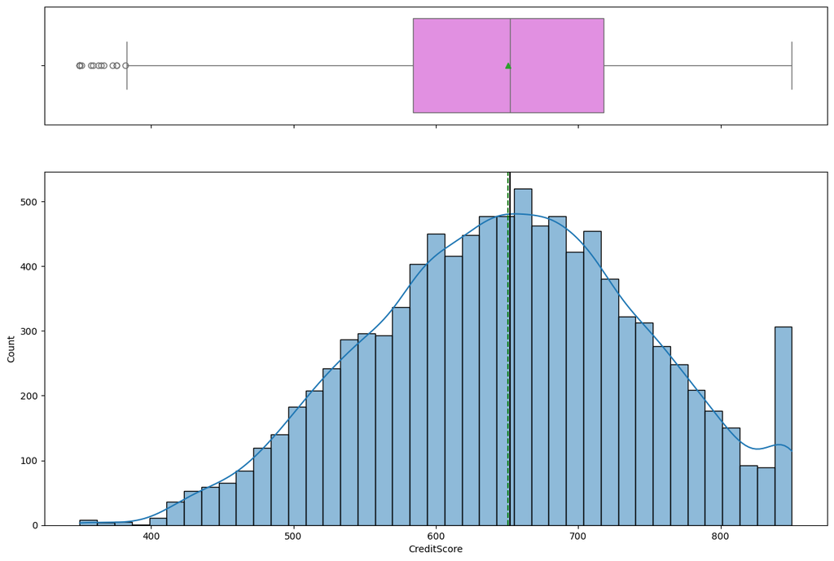

```python
histogram_boxplot(data, 'CreditScore', figsize=(15, 10),kde=True)
```

- The distribution is close to normal.
- There are outliers on the lower end, indicating customers with significantly lower credit scores.

#### `Age`

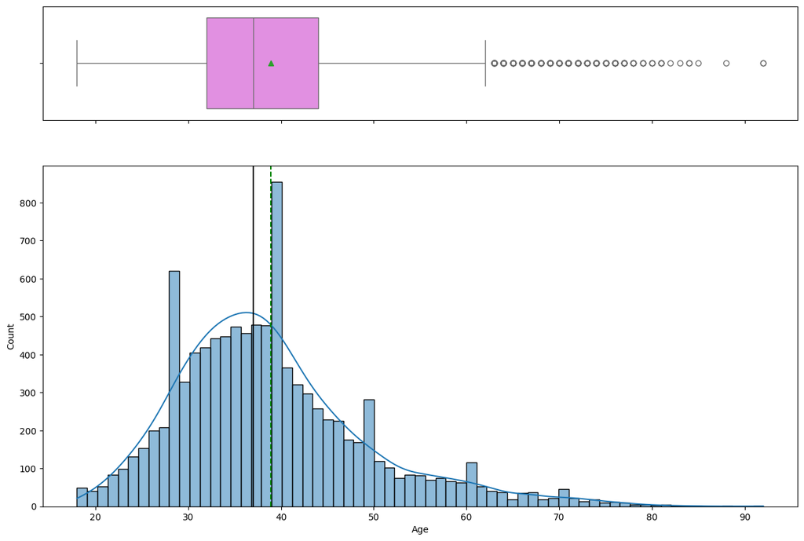

```python
histogram_boxplot(data, 'Age', figsize=(15, 10),kde=True)
```

- The distribution is right skewed.
- There are ouliers on the higher end, indicating customers with significantly higher ages.

#### `Tenure`

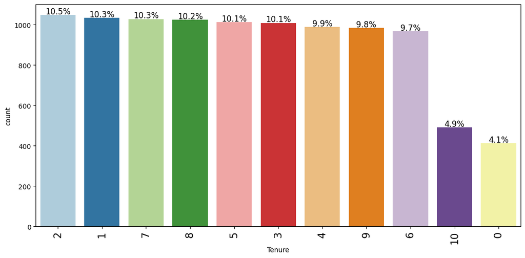

```python
labeled_barplot(data, 'Tenure', perc=True)
```

- Mostly the tenures are betwee 1 - 9.
- Looking at the distribution, customers with 0 tenure need to be reviewed to ensure it's valid and not a data entry error for 10.

#### `Balance`

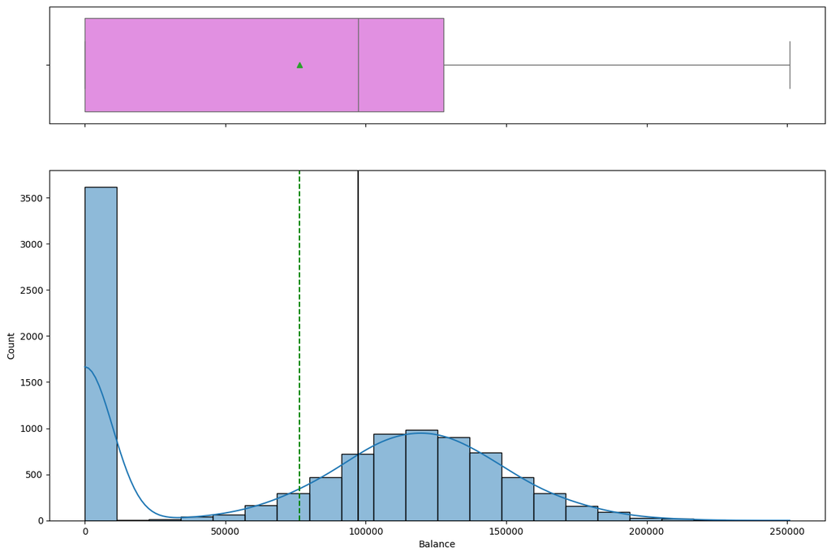

```python
histogram_boxplot(data, 'Balance', figsize=(15, 10), kde=True)
```

#### `NumOfProducts`

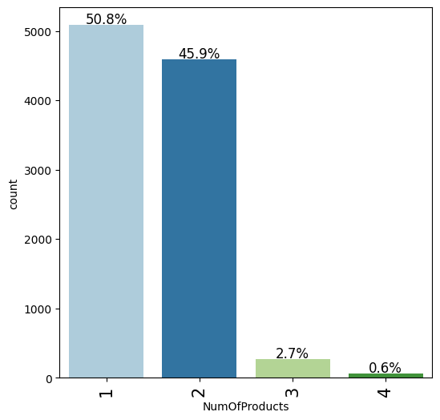

```python
labeled_barplot(data, 'NumOfProducts',perc=True)
```

- Most customers have 1 or 2 products.
- Very few customers have 4 products.

#### `EstimatedSalary`

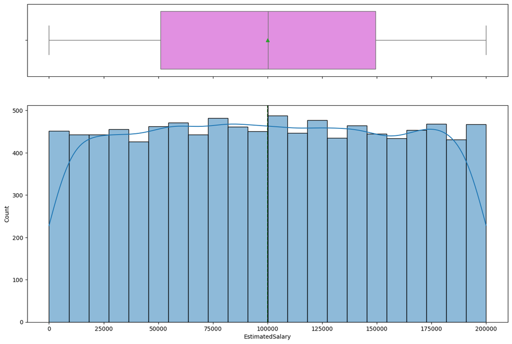

```python
histogram_boxplot(data, 'EstimatedSalary', figsize=(15, 10), kde=True)
```

- The distribution is approximately uniform.
- There are no significant outliers.

#### `Geography`

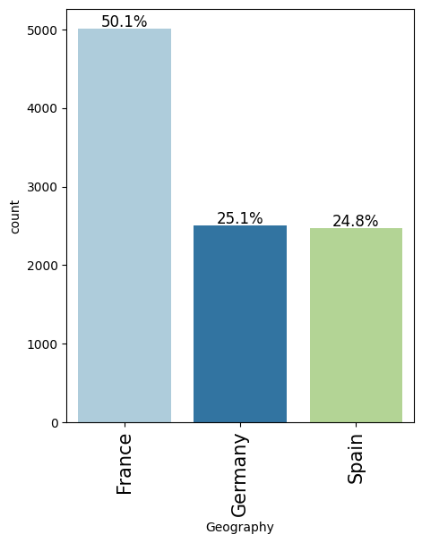

```python
labeled_barplot(data, 'Geography', perc=True)
```

- France has the most customers.
- Germany and Spain have similar customer counts.

#### `Gender`

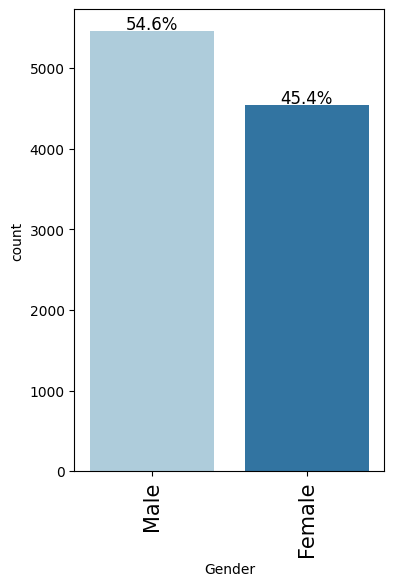

```python
labeled_barplot(data, 'Gender', perc=True)
```

- More male customers than females.

#### `HasCrCard`

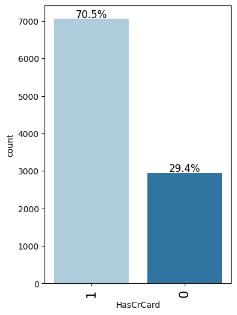

```python
labeled_barplot(data, 'HasCrCard', perc=True)
```

- Most customers (70.5%) have a credit card.

#### `IsActiveMember`

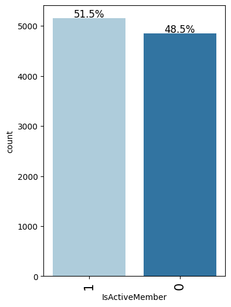

```python
labeled_barplot(data, 'IsActiveMember', perc=True)
```

- Slightly more active members.

### Bivariate Analysis

#### Correlation Check

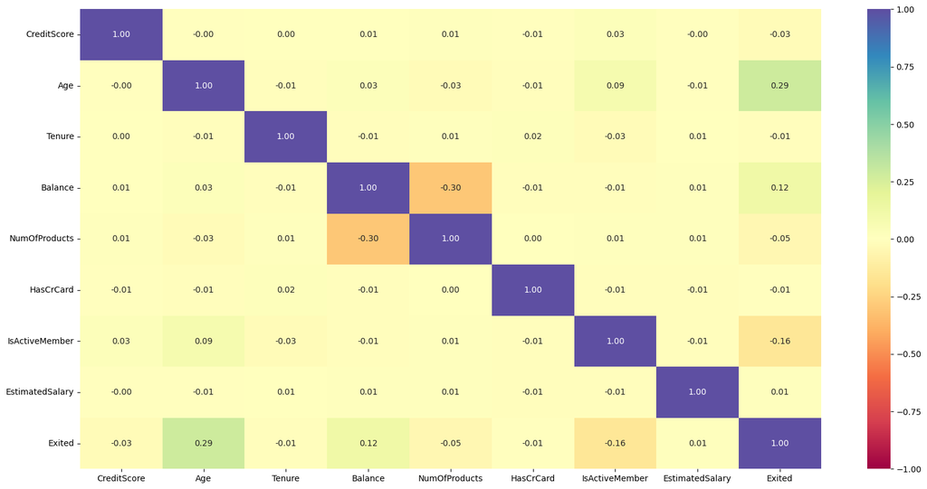

```python
plt.figure(figsize=(20,10))
sns.heatmap(data.corr(numeric_only=True),annot=True,vmin=-1,vmax=1,fmt='.2f',cmap="Spectral")
plt.show()
```

- `Age` and `Exited`: Moderate positive correlation. Older customers more likely to exit.
- `Balance` and `NumOfProducts`: Moderate negative correlation. More products, lower balance.
- `IsActiveMember` and `Exited`: Weak negative correlation. Inactive members slightly more likely to exit.
- `Balance` and `Exited`: Weak positive correlation. Customers with slightly higher balances are slightly more likely to exit.
- `IsActiveMember` and `Age`: Weak positive correlation. Slightly older customers are slightly more likely to be active members.
- Most other correlations are very weak or negligible.

#### `Exited` vs Numerical Features

```python
# 'HasCrCard','IsActiveMember' are boolean features and can be converted to categorical features for further analysis and model building
# Convert 'HasCrCard' and 'IsActiveMember' columns to categorical features
data['HasCrCard'] = data['HasCrCard'].astype('category')
data['IsActiveMember'] = data['IsActiveMember'].astype('category')
```

```python
numerical_features = data.select_dtypes('number').columns
numerical_features = numerical_features.drop('Exited')
```

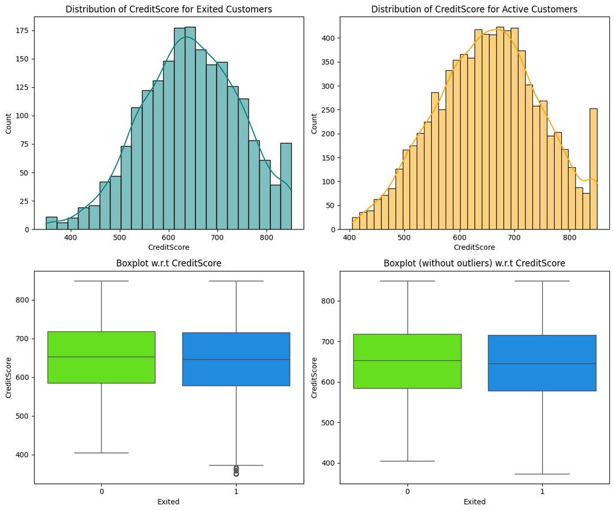

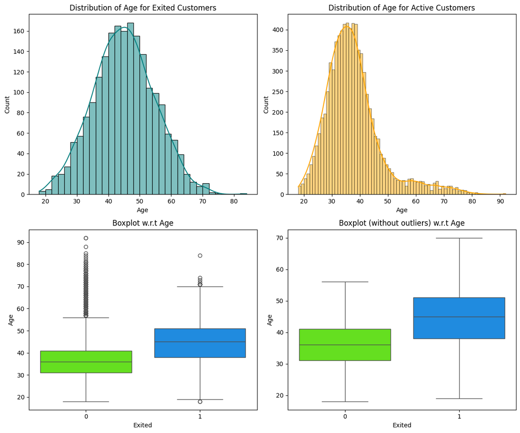

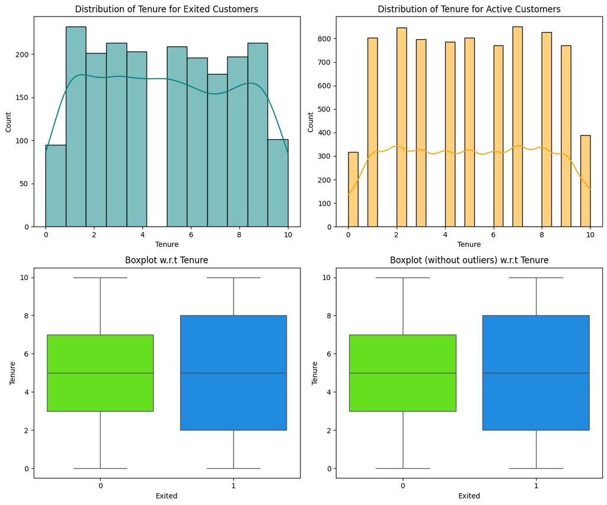

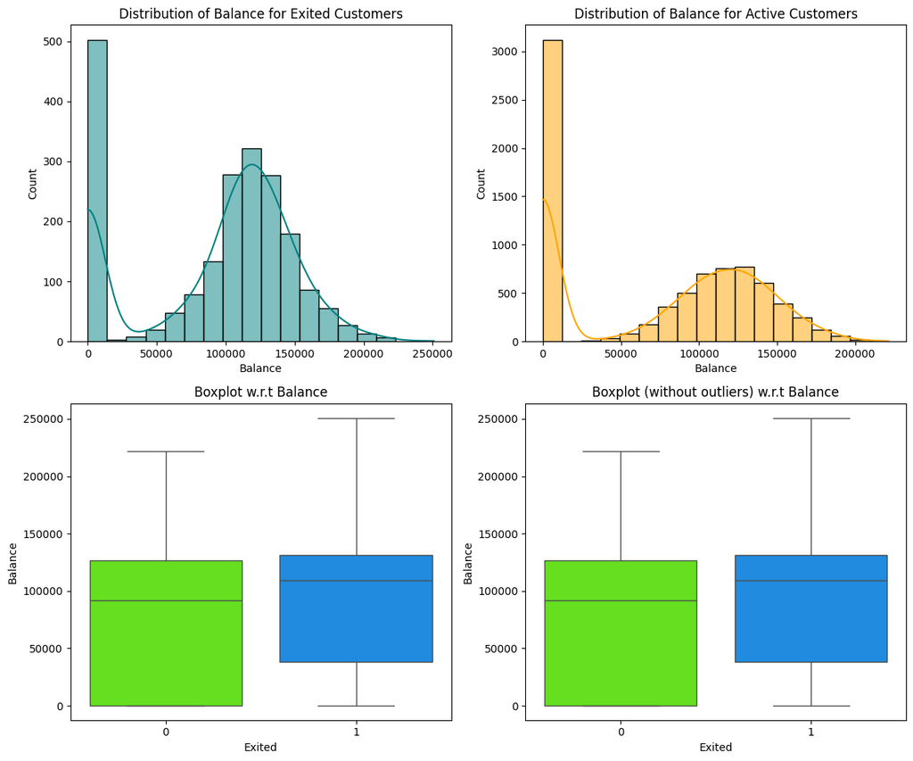

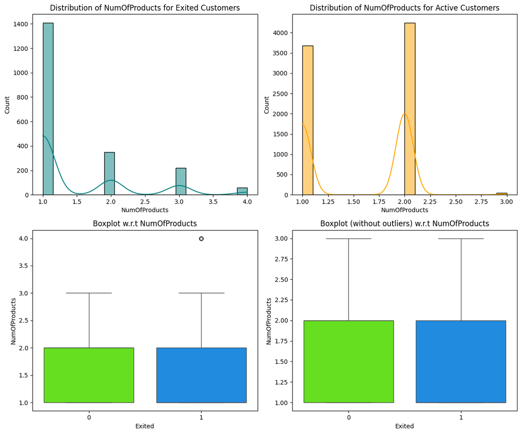

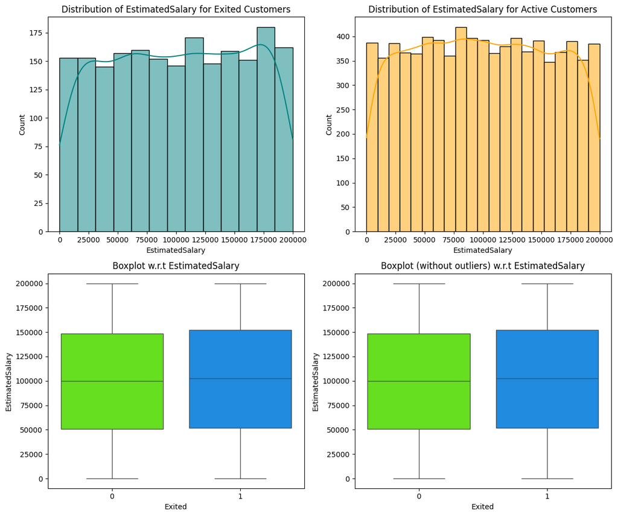

```python
# plotting the distribution plot for each numerical feature against Exited status
for feature in numerical_features:
    distribution_plot_wrt_target(data, feature,'Exited',["Exited Customers","Active Customers"])
```

#### `Exited` vs Categorical Features

```python
categorical_features = ['Geography','Gender','HasCrCard','IsActiveMember']
```

```
Exited        0     1    All
Geography
All        7963  2037  10000
Germany    1695   814   2509
France     4204   810   5014
Spain      2064   413   2477
------------------------------------------------------------------------------------------------------------------------
```

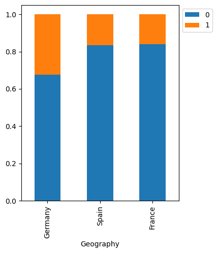

```
Exited     0     1    All
Gender
All     7963  2037  10000
Female  3404  1139   4543
Male    4559   898   5457
------------------------------------------------------------------------------------------------------------------------
```

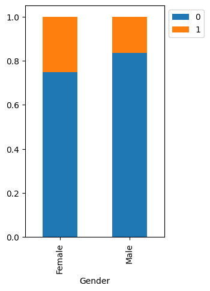

```
Exited        0     1    All
HasCrCard
All        7963  2037  10000
1          5631  1424   7055
0          2332   613   2945
------------------------------------------------------------------------------------------------------------------------
```

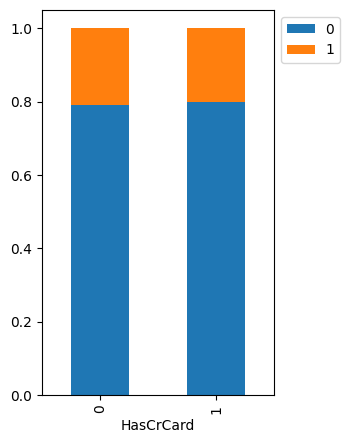

```
Exited             0     1    All
IsActiveMember
All             7963  2037  10000
0               3547  1302   4849
1               4416   735   5151
------------------------------------------------------------------------------------------------------------------------
```

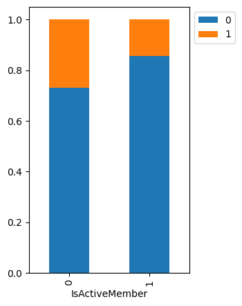

```python
# plotting the distribution plot for each categorical feature against Exited status
for feature in categorical_features:
    stacked_barplot(data, feature,'Exited')
```

- `Geography`: Customers from Germany have the highest exit rate. France and Spain have similar, lower exit rate.
- `Gender`: Female customers have a higher exit rate.
- `HasCrCard`: Having a credit card does not significantly impact the exit.
- `IsActiveMember`: Inactive customers are more likely to exit.

## Data Preprocessing

### Dummy Variable Creation

```python
# create a copy of data for further processing
df = data.copy()

# creating dummy variables
df = pd.get_dummies(df, columns=df.select_dtypes(include=["object", "category"]).columns.tolist(), drop_first=True)

# specifying the datatype of the independent variables data frame
df = df.astype(float)

df.head()
```

|  | CreditScore | Age | Tenure | Balance | NumOfProducts | EstimatedSalary | Exited | Geography_Germany | Geography_Spain | Gender_Male | HasCrCard_1 | IsActiveMember_1 |
| --- | --- | --- | --- | --- | --- | --- | --- | --- | --- | --- | --- | --- |
| 0 | 619.0 | 42.0 | 2.0 | 0.00 | 1.0 | 101348.88 | 1.0 | 0.0 | 0.0 | 0.0 | 1.0 | 1.0 |
| 1 | 608.0 | 41.0 | 1.0 | 83807.86 | 1.0 | 112542.58 | 0.0 | 0.0 | 1.0 | 0.0 | 0.0 | 1.0 |
| 2 | 502.0 | 42.0 | 8.0 | 159660.80 | 3.0 | 113931.57 | 1.0 | 0.0 | 0.0 | 0.0 | 1.0 | 0.0 |
| 3 | 699.0 | 39.0 | 1.0 | 0.00 | 2.0 | 93826.63 | 0.0 | 0.0 | 0.0 | 0.0 | 0.0 | 0.0 |
| 4 | 850.0 | 43.0 | 2.0 | 125510.82 | 1.0 | 79084.10 | 0.0 | 0.0 | 1.0 | 0.0 | 1.0 | 1.0 |

### Train-validation-test Split

```python
# defining the explanatory (independent) and response (dependent) variables
X = df.drop(["Exited"], axis=1)
y = df["Exited"]
```

```python
# splitting the data in 80:20 ratio for train and temporary data
x_train, x_temp, y_train, y_temp = train_test_split(X, y, test_size=0.2,random_state=1)
```

```python
# splitting the temporary data in 50:50 ratio for validation and test data
x_val,x_test,y_val,y_test = train_test_split(x_temp,y_temp,test_size=0.5,random_state=1)
```

```python
print("Number of rows in train data =", x_train.shape[0])
print("Number of rows in validation data =", x_val.shape[0])
print("Number of rows in test data =", x_test.shape[0])
```

```
Number of rows in train data = 8000
Number of rows in validation data = 1000
Number of rows in test data = 1000
```

### Data Normalization

```python
# Initialize the StandardScaler
scaler = StandardScaler()

# Fit the scaler to the numerical features columns in the x_train data
scaler.fit(x_train[numerical_features])
```

```
StandardScaler()
```

```python
# Transform selected numerical features in x_train, x_val, and x_test using the fitted scaler

x_train[numerical_features] = scaler.transform(x_train[numerical_features])
x_val[numerical_features] = scaler.transform(x_val[numerical_features])
x_test[numerical_features] = scaler.transform(x_test[numerical_features])
```

```python
x_train.head()
```

|  | CreditScore | Age | Tenure | Balance | NumOfProducts | EstimatedSalary | Geography_Germany | Geography_Spain | Gender_Male | HasCrCard_1 | IsActiveMember_1 |
| --- | --- | --- | --- | --- | --- | --- | --- | --- | --- | --- | --- |
| 2694 | -0.230820 | -0.944500 | -0.701742 | 0.588173 | 0.802257 | 0.427394 | 1.0 | 0.0 | 1.0 | 0.0 | 1.0 |
| 5140 | -0.251509 | -0.944500 | -0.355203 | 0.469849 | 0.802257 | -1.025487 | 0.0 | 0.0 | 0.0 | 0.0 | 0.0 |
| 2568 | -0.396330 | 0.774987 | 0.337876 | 0.858788 | -0.911510 | -0.944798 | 1.0 | 0.0 | 0.0 | 1.0 | 1.0 |
| 3671 | -0.044622 | 1.252622 | 0.337876 | 0.565604 | 0.802257 | -0.551946 | 1.0 | 0.0 | 0.0 | 0.0 | 1.0 |
| 7427 | 0.658795 | -0.562392 | 1.030954 | 0.730395 | -0.911510 | 1.083383 | 0.0 | 1.0 | 1.0 | 0.0 | 0.0 |

## Model Building

### Model Evaluation Criterion

The nature of predictions made by the neural network classification model will translate as follows:

- `True positives (TP)` are customers correctly predicted to churn by the model.
- `False negatives (FN)` are customers who actually churned but were not detected by the model.
- `False positives (FP)` are customers predicted to churn by the model, but they did not actually churn.

**Which metric to optimize?**

- We need to choose the metric that will ensure the maximum number of customers who will churn are correctly predicted by the neural network model.
- We would want `Recall` to be maximized. The higher the Recall, the greater the chances of minimizing false negatives.
- We want to minimize false negatives because if a model predicts that a customer will not churn when they actually will, it will result in lost revenue and potential damage to customer relationships.

**Let's define a function to output different metrics (including recall) on the train, validation and test set.**

```python
# defining a function to compute different metrics to check performance of a classification model built using sklearn
def model_performance(model, predictors, target):
    """
    Function to compute different metrics to check classification model performance

    model: classifier
    predictors: independent variables
    target: dependent variable
    """

    # predicting using the independent variables
    pred_probs = model.predict(predictors) # Get predicted probabilities
    pred = (pred_probs > 0.5).astype(int)  # Convert probabilities to binary predictions using a threshold of 0.5

    acc = accuracy_score(target, pred)  # to compute Accuracy
    recall = recall_score(target, pred)  # to compute Recall
    precision = precision_score(target, pred)  # to compute Precision
    f1 = f1_score(target, pred)  # to compute F1-score

    # creating a dataframe of metrics
    df_perf = pd.DataFrame(
        {
            "Accuracy": acc,
            "Recall": recall,
            "Precision": precision,
            "F1": f1

        },
        index=[0],
    )

    return df_perf
```

```python
columns = ["# hidden layers","# neurons - hidden layer","activation function - hidden layer ","# epochs","batch size","optimizer","Dropout","SMOTE","time(secs)","Train_loss","Valid_loss","Train_Recall","Valid_Recall"]

results = pd.DataFrame(columns=columns)
```

```python
#Defining "Recall" as the metrics to be used for all the models.
metrics = [tf.keras.metrics.Recall(name="recall")]
```

We'll be using the same batch size and epochs throughout, so let's define two variables for the same

```python
epochs = 25
batch_size = 32
```

### Neural Network with SGD Optimizer

```python
# clears the current Keras session, resetting all layers and models previously created, freeing up memory and resources.
tf.keras.backend.clear_session()
```

```python
#Initializing the neural network
model1 = Sequential()
model1.add(Dense(128,activation="relu",input_dim=x_train.shape[1]))
model1.add(Dense(64,activation="relu"))
model1.add(Dense(1,activation="sigmoid"))
```

```python
model1.summary()
```

```
Model: "sequential"
```

```
┏━━━━━━━━━━━━━━━━━━━━━━━━━━━━━━━━━━━━━━┳━━━━━━━━━━━━━━━━━━━━━━━━━━━━━┳━━━━━━━━━━━━━━━━━┓
┃ Layer (type)                         ┃ Output Shape                ┃         Param # ┃
┡━━━━━━━━━━━━━━━━━━━━━━━━━━━━━━━━━━━━━━╇━━━━━━━━━━━━━━━━━━━━━━━━━━━━━╇━━━━━━━━━━━━━━━━━┩
│ dense (Dense)                        │ (None, 128)                 │           1,536 │
├──────────────────────────────────────┼─────────────────────────────┼─────────────────┤
│ dense_1 (Dense)                      │ (None, 64)                  │           8,256 │
├──────────────────────────────────────┼─────────────────────────────┼─────────────────┤
│ dense_2 (Dense)                      │ (None, 1)                   │              65 │
└──────────────────────────────────────┴─────────────────────────────┴─────────────────┘
```

```
 Total params: 9,857 (38.50 KB)
```

```
 Trainable params: 9,857 (38.50 KB)
```

```
 Non-trainable params: 0 (0.00 B)
```

```python
optimizer = keras.optimizers.SGD()    # defining SGD as the optimizer to be used
model1.compile(loss="binary_crossentropy", optimizer=optimizer, metrics=metrics,run_eagerly=True)
```

```python
start = time.time()
history = model1.fit(x_train, y_train, validation_data=(x_val,y_val) , batch_size=batch_size, epochs=epochs)
end=time.time()
```

```
250/250 ━━━━━━━━━━━━━━━━━━━━ 6s 24ms/step - loss: 0.6062 - recall: 0.3206 - val_loss: 0.4383 - val_recall: 0.0000e+00
250/250 ━━━━━━━━━━━━━━━━━━━━ 10s 24ms/step - loss: 0.4555 - recall: 2.3104e-04 - val_loss: 0.4070 - val_recall: 0.0000e+00
250/250 ━━━━━━━━━━━━━━━━━━━━ 5s 22ms/step - loss: 0.4323 - recall: 0.0071 - val_loss: 0.3887 - val_recall: 0.0447
250/250 ━━━━━━━━━━━━━━━━━━━━ 10s 22ms/step - loss: 0.4177 - recall: 0.0501 - val_loss: 0.3766 - val_recall: 0.1285
250/250 ━━━━━━━━━━━━━━━━━━━━ 10s 22ms/step - loss: 0.4073 - recall: 0.1081 - val_loss: 0.3676 - val_recall: 0.2011
250/250 ━━━━━━━━━━━━━━━━━━━━ 10s 22ms/step - loss: 0.3987 - recall: 0.1518 - val_loss: 0.3600 - val_recall: 0.2291
250/250 ━━━━━━━━━━━━━━━━━━━━ 11s 26ms/step - loss: 0.3909 - recall: 0.2042 - val_loss: 0.3534 - val_recall: 0.2626
250/250 ━━━━━━━━━━━━━━━━━━━━ 10s 24ms/step - loss: 0.3838 - recall: 0.2573 - val_loss: 0.3474 - val_recall: 0.2849
250/250 ━━━━━━━━━━━━━━━━━━━━ 10s 24ms/step - loss: 0.3773 - recall: 0.2907 - val_loss: 0.3421 - val_recall: 0.3184
250/250 ━━━━━━━━━━━━━━━━━━━━ 10s 21ms/step - loss: 0.3715 - recall: 0.3127 - val_loss: 0.3373 - val_recall: 0.3352
250/250 ━━━━━━━━━━━━━━━━━━━━ 6s 22ms/step - loss: 0.3663 - recall: 0.3456 - val_loss: 0.3331 - val_recall: 0.3520
250/250 ━━━━━━━━━━━━━━━━━━━━ 5s 21ms/step - loss: 0.3619 - recall: 0.3718 - val_loss: 0.3294 - val_recall: 0.3631
250/250 ━━━━━━━━━━━━━━━━━━━━ 10s 22ms/step - loss: 0.3581 - recall: 0.3920 - val_loss: 0.3262 - val_recall: 0.3855
250/250 ━━━━━━━━━━━━━━━━━━━━ 10s 21ms/step - loss: 0.3550 - recall: 0.4053 - val_loss: 0.3235 - val_recall: 0.3911
250/250 ━━━━━━━━━━━━━━━━━━━━ 6s 24ms/step - loss: 0.3524 - recall: 0.4180 - val_loss: 0.3211 - val_recall: 0.4078
250/250 ━━━━━━━━━━━━━━━━━━━━ 5s 21ms/step - loss: 0.3502 - recall: 0.4226 - val_loss: 0.3191 - val_recall: 0.4190
250/250 ━━━━━━━━━━━━━━━━━━━━ 6s 24ms/step - loss: 0.3483 - recall: 0.4273 - val_loss: 0.3173 - val_recall: 0.4358
250/250 ━━━━━━━━━━━━━━━━━━━━ 5s 21ms/step - loss: 0.3468 - recall: 0.4296 - val_loss: 0.3158 - val_recall: 0.4413
250/250 ━━━━━━━━━━━━━━━━━━━━ 10s 22ms/step - loss: 0.3454 - recall: 0.4365 - val_loss: 0.3145 - val_recall: 0.4469
250/250 ━━━━━━━━━━━━━━━━━━━━ 5s 22ms/step - loss: 0.3442 - recall: 0.4410 - val_loss: 0.3134 - val_recall: 0.4469
250/250 ━━━━━━━━━━━━━━━━━━━━ 10s 21ms/step - loss: 0.3432 - recall: 0.4413 - val_loss: 0.3124 - val_recall: 0.4581
250/250 ━━━━━━━━━━━━━━━━━━━━ 10s 21ms/step - loss: 0.3422 - recall: 0.4443 - val_loss: 0.3115 - val_recall: 0.4581
250/250 ━━━━━━━━━━━━━━━━━━━━ 10s 21ms/step - loss: 0.3413 - recall: 0.4478 - val_loss: 0.3107 - val_recall: 0.4581
250/250 ━━━━━━━━━━━━━━━━━━━━ 10s 21ms/step - loss: 0.3405 - recall: 0.4513 - val_loss: 0.3099 - val_recall: 0.4581
250/250 ━━━━━━━━━━━━━━━━━━━━ 10s 21ms/step - loss: 0.3397 - recall: 0.4544 - val_loss: 0.3092 - val_recall: 0.4637
```

```python
print("Time taken in seconds ",end-start)
```

```
Time taken in seconds  218.90901446342468
```

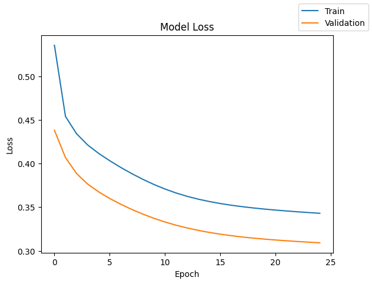

```python
plot(history, "loss")
```

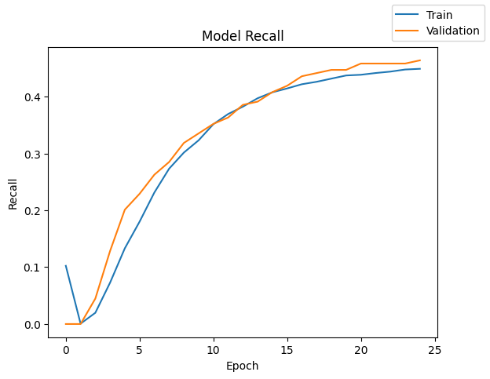

```python
plot(history,'recall')
```

```python
results.loc[0]=['2','[128,64]','[relu,relu]',epochs,batch_size,'SGD','-','-',(end-start),history.history["loss"][-1],history.history["val_loss"][-1],history.history["recall"][-1],history.history["val_recall"][-1]]
```

```python
results
```

|  | # hidden layers | # neurons - hidden layer | activation function - hidden layer | # epochs | batch size | optimizer | Dropout | SMOTE | time(secs) | Train_loss | Valid_loss | Train_Recall | Valid_Recall |
| --- | --- | --- | --- | --- | --- | --- | --- | --- | --- | --- | --- | --- | --- |
| 0 | 2 | [128,64] | [relu,relu] | 25 | 32 | SGD | - | - | 218.909014 | 0.34303 | 0.309187 | 0.448829 | 0.463687 |

- Both training and validation loss decreased smoothly, indicating stable learning.
- Both training and validation recall improved steadily, but plateaued towards the end.
- Achieved moderate recall (< 0.5) on both training and validation sets.Needs improvement.
- Training time was fast.

## Model Performance Improvement

### Neural Network with Adam Optimizer

```python
# clears the current Keras session, resetting all layers and models previously created, freeing up memory and resources.
tf.keras.backend.clear_session()
```

```python
#Initializing the neural network
model2 = Sequential()
model2.add(Dense(128,activation="relu",input_dim=x_train.shape[1]))
model2.add(Dense(64,activation="relu"))
model2.add(Dense(1,activation="sigmoid"))
```

```python
model2.summary()
```

```
Model: "sequential"
```

```
┏━━━━━━━━━━━━━━━━━━━━━━━━━━━━━━━━━━━━━━┳━━━━━━━━━━━━━━━━━━━━━━━━━━━━━┳━━━━━━━━━━━━━━━━━┓
┃ Layer (type)                         ┃ Output Shape                ┃         Param # ┃
┡━━━━━━━━━━━━━━━━━━━━━━━━━━━━━━━━━━━━━━╇━━━━━━━━━━━━━━━━━━━━━━━━━━━━━╇━━━━━━━━━━━━━━━━━┩
│ dense (Dense)                        │ (None, 128)                 │           1,536 │
├──────────────────────────────────────┼─────────────────────────────┼─────────────────┤
│ dense_1 (Dense)                      │ (None, 64)                  │           8,256 │
├──────────────────────────────────────┼─────────────────────────────┼─────────────────┤
│ dense_2 (Dense)                      │ (None, 1)                   │              65 │
└──────────────────────────────────────┴─────────────────────────────┴─────────────────┘
```

```
 Total params: 9,857 (38.50 KB)
```

```
 Trainable params: 9,857 (38.50 KB)
```

```
 Non-trainable params: 0 (0.00 B)
```

```python
optimizer = keras.optimizers.Adam()    # defining SGD as the optimizer to be used
model2.compile(loss="binary_crossentropy", optimizer=optimizer, metrics=metrics,run_eagerly=True)
```

```python
start = time.time()
history = model2.fit(x_train, y_train, validation_data=(x_val,y_val) , batch_size=batch_size, epochs=epochs)
end=time.time()
```

```
250/250 ━━━━━━━━━━━━━━━━━━━━ 9s 35ms/step - loss: 0.4555 - recall: 0.2127 - val_loss: 0.3322 - val_recall: 0.3855
250/250 ━━━━━━━━━━━━━━━━━━━━ 11s 37ms/step - loss: 0.3618 - recall: 0.3947 - val_loss: 0.3141 - val_recall: 0.4413
250/250 ━━━━━━━━━━━━━━━━━━━━ 10s 38ms/step - loss: 0.3500 - recall: 0.4274 - val_loss: 0.3080 - val_recall: 0.4469
250/250 ━━━━━━━━━━━━━━━━━━━━ 10s 37ms/step - loss: 0.3437 - recall: 0.4514 - val_loss: 0.3033 - val_recall: 0.4637
250/250 ━━━━━━━━━━━━━━━━━━━━ 9s 38ms/step - loss: 0.3389 - recall: 0.4614 - val_loss: 0.3000 - val_recall: 0.4972
250/250 ━━━━━━━━━━━━━━━━━━━━ 10s 37ms/step - loss: 0.3348 - recall: 0.4713 - val_loss: 0.2972 - val_recall: 0.5028
250/250 ━━━━━━━━━━━━━━━━━━━━ 9s 35ms/step - loss: 0.3315 - recall: 0.4781 - val_loss: 0.2953 - val_recall: 0.5251
250/250 ━━━━━━━━━━━━━━━━━━━━ 9s 38ms/step - loss: 0.3284 - recall: 0.4811 - val_loss: 0.2943 - val_recall: 0.5251
250/250 ━━━━━━━━━━━━━━━━━━━━ 10s 37ms/step - loss: 0.3259 - recall: 0.4839 - val_loss: 0.2938 - val_recall: 0.5196
250/250 ━━━━━━━━━━━━━━━━━━━━ 9s 37ms/step - loss: 0.3238 - recall: 0.4910 - val_loss: 0.2933 - val_recall: 0.5196
250/250 ━━━━━━━━━━━━━━━━━━━━ 10s 37ms/step - loss: 0.3216 - recall: 0.4957 - val_loss: 0.2927 - val_recall: 0.5251
250/250 ━━━━━━━━━━━━━━━━━━━━ 9s 35ms/step - loss: 0.3196 - recall: 0.4997 - val_loss: 0.2923 - val_recall: 0.5419
250/250 ━━━━━━━━━━━━━━━━━━━━ 11s 36ms/step - loss: 0.3178 - recall: 0.5019 - val_loss: 0.2921 - val_recall: 0.5363
250/250 ━━━━━━━━━━━━━━━━━━━━ 10s 37ms/step - loss: 0.3160 - recall: 0.5075 - val_loss: 0.2919 - val_recall: 0.5475
250/250 ━━━━━━━━━━━━━━━━━━━━ 10s 38ms/step - loss: 0.3140 - recall: 0.5099 - val_loss: 0.2921 - val_recall: 0.5419
250/250 ━━━━━━━━━━━━━━━━━━━━ 10s 39ms/step - loss: 0.3122 - recall: 0.5164 - val_loss: 0.2922 - val_recall: 0.5307
250/250 ━━━━━━━━━━━━━━━━━━━━ 10s 38ms/step - loss: 0.3105 - recall: 0.5178 - val_loss: 0.2925 - val_recall: 0.5307
250/250 ━━━━━━━━━━━━━━━━━━━━ 9s 35ms/step - loss: 0.3086 - recall: 0.5280 - val_loss: 0.2931 - val_recall: 0.5307
250/250 ━━━━━━━━━━━━━━━━━━━━ 10s 36ms/step - loss: 0.3071 - recall: 0.5304 - val_loss: 0.2934 - val_recall: 0.5419
250/250 ━━━━━━━━━━━━━━━━━━━━ 9s 38ms/step - loss: 0.3054 - recall: 0.5362 - val_loss: 0.2936 - val_recall: 0.5419
250/250 ━━━━━━━━━━━━━━━━━━━━ 9s 38ms/step - loss: 0.3037 - recall: 0.5431 - val_loss: 0.2939 - val_recall: 0.5419
250/250 ━━━━━━━━━━━━━━━━━━━━ 9s 38ms/step - loss: 0.3022 - recall: 0.5455 - val_loss: 0.2939 - val_recall: 0.5363
250/250 ━━━━━━━━━━━━━━━━━━━━ 11s 40ms/step - loss: 0.3003 - recall: 0.5464 - val_loss: 0.2945 - val_recall: 0.5307
250/250 ━━━━━━━━━━━━━━━━━━━━ 10s 39ms/step - loss: 0.2986 - recall: 0.5486 - val_loss: 0.2948 - val_recall: 0.5419
250/250 ━━━━━━━━━━━━━━━━━━━━ 10s 38ms/step - loss: 0.2968 - recall: 0.5503 - val_loss: 0.2956 - val_recall: 0.5419
```

```python
print("Time taken in seconds ",end-start)
```

```
Time taken in seconds  246.185711145401
```

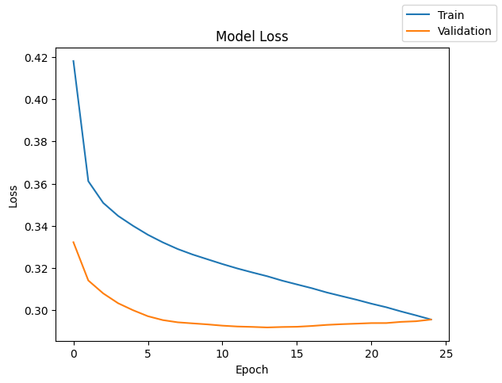

```python
plot(history, "loss")
```

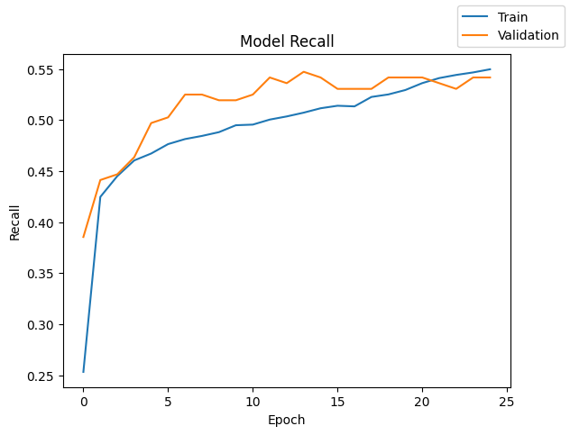

```python
plot(history,'recall')
```

```python
results.loc[1]=['2','[128,64]','[relu,relu]',epochs,batch_size,'Adam','-','-',(end-start),history.history["loss"][-1],history.history["val_loss"][-1],history.history["recall"][-1],history.history["val_recall"][-1]]
```

```python
results
```

|  | # hidden layers | # neurons - hidden layer | activation function - hidden layer | # epochs | batch size | optimizer | Dropout | SMOTE | time(secs) | Train_loss | Valid_loss | Train_Recall | Valid_Recall |
| --- | --- | --- | --- | --- | --- | --- | --- | --- | --- | --- | --- | --- | --- |
| 0 | 2 | [128,64] | [relu,relu] | 25 | 32 | SGD | - | - | 218.909014 | 0.343030 | 0.309187 | 0.448829 | 0.463687 |
| 1 | 2 | [128,64] | [relu,relu] | 25 | 32 | Adam | - | - | 246.185711 | 0.295605 | 0.295582 | 0.549938 | 0.541899 |

- Achieved significantly higher recall (~ 0.54) compared to the SGD model.
- Training time is higher than the SGD model.
- Less difference between training and validation recall compared to the SGD model, indicating less overfitting.

### Neural Network with Adam Optimizer and Dropout

```python
# clears the current Keras session, resetting all layers and models previously created, freeing up memory and resources.
tf.keras.backend.clear_session()
```

```python
# defining the dropout ratio
# 20% of the neurons will be switched off
dropout_rate = 0.2
```

```python
#Initializing the neural network
model3 = Sequential()
model3.add(Dense(128,activation="relu",input_dim=x_train.shape[1]))
model3.add(Dropout(dropout_rate))
model3.add(Dense(64,activation="relu"))
model3.add(Dropout(dropout_rate))
model3.add(Dense(1,activation="sigmoid"))
```

```python
model3.summary()
```

```
Model: "sequential"
```

```
┏━━━━━━━━━━━━━━━━━━━━━━━━━━━━━━━━━━━━━━┳━━━━━━━━━━━━━━━━━━━━━━━━━━━━━┳━━━━━━━━━━━━━━━━━┓
┃ Layer (type)                         ┃ Output Shape                ┃         Param # ┃
┡━━━━━━━━━━━━━━━━━━━━━━━━━━━━━━━━━━━━━━╇━━━━━━━━━━━━━━━━━━━━━━━━━━━━━╇━━━━━━━━━━━━━━━━━┩
│ dense (Dense)                        │ (None, 128)                 │           1,536 │
├──────────────────────────────────────┼─────────────────────────────┼─────────────────┤
│ dropout (Dropout)                    │ (None, 128)                 │               0 │
├──────────────────────────────────────┼─────────────────────────────┼─────────────────┤
│ dense_1 (Dense)                      │ (None, 64)                  │           8,256 │
├──────────────────────────────────────┼─────────────────────────────┼─────────────────┤
│ dropout_1 (Dropout)                  │ (None, 64)                  │               0 │
├──────────────────────────────────────┼─────────────────────────────┼─────────────────┤
│ dense_2 (Dense)                      │ (None, 1)                   │              65 │
└──────────────────────────────────────┴─────────────────────────────┴─────────────────┘
```

```
 Total params: 9,857 (38.50 KB)
```

```
 Trainable params: 9,857 (38.50 KB)
```

```
 Non-trainable params: 0 (0.00 B)
```

```python
optimizer = keras.optimizers.Adam()    # defining Adam as the optimizer to be used
model3.compile(loss="binary_crossentropy", optimizer=optimizer, metrics=metrics,run_eagerly=True)
```

```python
start = time.time()
history = model3.fit(x_train, y_train, validation_data=(x_val,y_val) , batch_size=batch_size, epochs=epochs)
end=time.time()
```

```
250/250 ━━━━━━━━━━━━━━━━━━━━ 11s 45ms/step - loss: 0.5179 - recall: 0.2438 - val_loss: 0.3423 - val_recall: 0.3855
250/250 ━━━━━━━━━━━━━━━━━━━━ 11s 45ms/step - loss: 0.3785 - recall: 0.3802 - val_loss: 0.3196 - val_recall: 0.4302
250/250 ━━━━━━━━━━━━━━━━━━━━ 11s 45ms/step - loss: 0.3655 - recall: 0.4019 - val_loss: 0.3145 - val_recall: 0.4358
250/250 ━━━━━━━━━━━━━━━━━━━━ 20s 45ms/step - loss: 0.3579 - recall: 0.4262 - val_loss: 0.3098 - val_recall: 0.4749
250/250 ━━━━━━━━━━━━━━━━━━━━ 20s 45ms/step - loss: 0.3521 - recall: 0.4492 - val_loss: 0.3057 - val_recall: 0.4916
250/250 ━━━━━━━━━━━━━━━━━━━━ 11s 45ms/step - loss: 0.3483 - recall: 0.4470 - val_loss: 0.3027 - val_recall: 0.4972
250/250 ━━━━━━━━━━━━━━━━━━━━ 20s 43ms/step - loss: 0.3511 - recall: 0.4573 - val_loss: 0.3022 - val_recall: 0.4916
250/250 ━━━━━━━━━━━━━━━━━━━━ 21s 45ms/step - loss: 0.3413 - recall: 0.4672 - val_loss: 0.3015 - val_recall: 0.5028
250/250 ━━━━━━━━━━━━━━━━━━━━ 21s 45ms/step - loss: 0.3379 - recall: 0.4776 - val_loss: 0.2997 - val_recall: 0.4916
250/250 ━━━━━━━━━━━━━━━━━━━━ 11s 45ms/step - loss: 0.3406 - recall: 0.4727 - val_loss: 0.2969 - val_recall: 0.5084
250/250 ━━━━━━━━━━━━━━━━━━━━ 11s 44ms/step - loss: 0.3332 - recall: 0.4794 - val_loss: 0.2975 - val_recall: 0.5251
250/250 ━━━━━━━━━━━━━━━━━━━━ 21s 45ms/step - loss: 0.3369 - recall: 0.4743 - val_loss: 0.2975 - val_recall: 0.4916
250/250 ━━━━━━━━━━━━━━━━━━━━ 20s 43ms/step - loss: 0.3297 - recall: 0.4947 - val_loss: 0.2937 - val_recall: 0.5084
250/250 ━━━━━━━━━━━━━━━━━━━━ 11s 44ms/step - loss: 0.3360 - recall: 0.5004 - val_loss: 0.2954 - val_recall: 0.5196
250/250 ━━━━━━━━━━━━━━━━━━━━ 11s 45ms/step - loss: 0.3328 - recall: 0.4846 - val_loss: 0.2957 - val_recall: 0.5196
250/250 ━━━━━━━━━━━━━━━━━━━━ 11s 45ms/step - loss: 0.3283 - recall: 0.5038 - val_loss: 0.2941 - val_recall: 0.5363
250/250 ━━━━━━━━━━━━━━━━━━━━ 11s 44ms/step - loss: 0.3261 - recall: 0.4942 - val_loss: 0.2959 - val_recall: 0.5251
250/250 ━━━━━━━━━━━━━━━━━━━━ 21s 45ms/step - loss: 0.3308 - recall: 0.4788 - val_loss: 0.2928 - val_recall: 0.5363
250/250 ━━━━━━━━━━━━━━━━━━━━ 20s 45ms/step - loss: 0.3265 - recall: 0.4880 - val_loss: 0.2922 - val_recall: 0.5251
250/250 ━━━━━━━━━━━━━━━━━━━━ 11s 45ms/step - loss: 0.3218 - recall: 0.4909 - val_loss: 0.2926 - val_recall: 0.4972
250/250 ━━━━━━━━━━━━━━━━━━━━ 11s 44ms/step - loss: 0.3231 - recall: 0.4844 - val_loss: 0.2928 - val_recall: 0.5140
250/250 ━━━━━━━━━━━━━━━━━━━━ 20s 43ms/step - loss: 0.3208 - recall: 0.5024 - val_loss: 0.2925 - val_recall: 0.5084
250/250 ━━━━━━━━━━━━━━━━━━━━ 21s 45ms/step - loss: 0.3278 - recall: 0.4934 - val_loss: 0.2928 - val_recall: 0.5363
250/250 ━━━━━━━━━━━━━━━━━━━━ 11s 45ms/step - loss: 0.3203 - recall: 0.5045 - val_loss: 0.2933 - val_recall: 0.5307
250/250 ━━━━━━━━━━━━━━━━━━━━ 21s 45ms/step - loss: 0.3191 - recall: 0.5001 - val_loss: 0.2904 - val_recall: 0.5251
```

```python
print("Time taken in seconds ",end-start)
```

```
Time taken in seconds  391.04450273513794
```

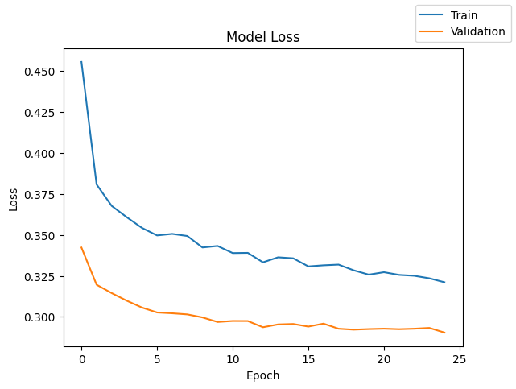

```python
plot(history, "loss")
```

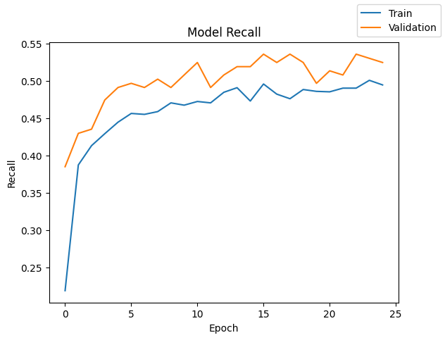

```python
plot(history,'recall')
```

```python
results.loc[2]=['2','[128,64]','[relu,relu]',epochs,batch_size,'Adam','[0.2,0.2]','-',(end-start),history.history["loss"][-1],history.history["val_loss"][-1],history.history["recall"][-1],history.history["val_recall"][-1]]
```

```python
results
```

|  | # hidden layers | # neurons - hidden layer | activation function - hidden layer | # epochs | batch size | optimizer | Dropout | SMOTE | time(secs) | Train_loss | Valid_loss | Train_Recall | Valid_Recall |
| --- | --- | --- | --- | --- | --- | --- | --- | --- | --- | --- | --- | --- | --- |
| 0 | 2 | [128,64] | [relu,relu] | 25 | 32 | SGD | - | - | 218.909014 | 0.343030 | 0.309187 | 0.448829 | 0.463687 |
| 1 | 2 | [128,64] | [relu,relu] | 25 | 32 | Adam | - | - | 246.185711 | 0.295605 | 0.295582 | 0.549938 | 0.541899 |
| 2 | 2 | [128,64] | [relu,relu] | 25 | 32 | Adam | [0.2,0.2] | - | 391.044503 | 0.321105 | 0.290420 | 0.495068 | 0.525140 |

### Neural Network with Balanced Data (by applying SMOTE) and SGD Optimizer

```python
# Synthetic Minority Over Sampling Technique
sm = SMOTE(sampling_strategy=1, k_neighbors=5, random_state=1)
x_train_over, y_train_over = sm.fit_resample(x_train, y_train)
```

```python
print("Before OverSampling, count of label '1': {}".format(sum(y_train == 1)))
print("Before OverSampling, count of label '0': {} \n".format(sum(y_train == 0)))

print("After OverSampling, count of label '1': {}".format(sum(y_train_over == 1)))
print("After OverSampling, count of label '0': {} \n".format(sum(y_train_over == 0)))

print("After OverSampling, the shape of train_X: {}".format(x_train_over.shape))
print("After OverSampling, the shape of train_y: {} \n".format(y_train_over.shape))
```

```
Before OverSampling, count of label '1': 1622
Before OverSampling, count of label '0': 6378

After OverSampling, count of label '1': 6378
After OverSampling, count of label '0': 6378

After OverSampling, the shape of train_X: (12756, 11)
After OverSampling, the shape of train_y: (12756,)
```

```python
# clears the current Keras session, resetting all layers and models previously created, freeing up memory and resources.
tf.keras.backend.clear_session()
```

```python
#Initializing the neural network
model4 = Sequential()
model4.add(Dense(128,activation="relu",input_dim=x_train.shape[1]))
model4.add(Dense(64,activation="relu"))
model4.add(Dense(1,activation="sigmoid"))
```

```python
model4.summary()
```

```
Model: "sequential"
```

```
┏━━━━━━━━━━━━━━━━━━━━━━━━━━━━━━━━━━━━━━┳━━━━━━━━━━━━━━━━━━━━━━━━━━━━━┳━━━━━━━━━━━━━━━━━┓
┃ Layer (type)                         ┃ Output Shape                ┃         Param # ┃
┡━━━━━━━━━━━━━━━━━━━━━━━━━━━━━━━━━━━━━━╇━━━━━━━━━━━━━━━━━━━━━━━━━━━━━╇━━━━━━━━━━━━━━━━━┩
│ dense (Dense)                        │ (None, 128)                 │           1,536 │
├──────────────────────────────────────┼─────────────────────────────┼─────────────────┤
│ dense_1 (Dense)                      │ (None, 64)                  │           8,256 │
├──────────────────────────────────────┼─────────────────────────────┼─────────────────┤
│ dense_2 (Dense)                      │ (None, 1)                   │              65 │
└──────────────────────────────────────┴─────────────────────────────┴─────────────────┘
```

```
 Total params: 9,857 (38.50 KB)
```

```
 Trainable params: 9,857 (38.50 KB)
```

```
 Non-trainable params: 0 (0.00 B)
```

```python
optimizer = keras.optimizers.SGD()    # defining SGD as the optimizer to be used
model4.compile(loss="binary_crossentropy", optimizer=optimizer, metrics=metrics,run_eagerly=True)
```

```python
start = time.time()
history = model4.fit(x_train_over, y_train_over, validation_data=(x_val,y_val) , batch_size=batch_size, epochs=epochs)
end=time.time()
```

```
399/399 ━━━━━━━━━━━━━━━━━━━━ 9s 23ms/step - loss: 0.6537 - recall: 0.4828 - val_loss: 0.5889 - val_recall: 0.7709
399/399 ━━━━━━━━━━━━━━━━━━━━ 9s 21ms/step - loss: 0.5756 - recall: 0.7400 - val_loss: 0.5401 - val_recall: 0.7821
399/399 ━━━━━━━━━━━━━━━━━━━━ 9s 23ms/step - loss: 0.5345 - recall: 0.7581 - val_loss: 0.5096 - val_recall: 0.7989
399/399 ━━━━━━━━━━━━━━━━━━━━ 10s 23ms/step - loss: 0.5070 - recall: 0.7698 - val_loss: 0.4870 - val_recall: 0.7989
399/399 ━━━━━━━━━━━━━━━━━━━━ 10s 23ms/step - loss: 0.4885 - recall: 0.7743 - val_loss: 0.4724 - val_recall: 0.7654
399/399 ━━━━━━━━━━━━━━━━━━━━ 10s 23ms/step - loss: 0.4767 - recall: 0.7791 - val_loss: 0.4625 - val_recall: 0.7598
399/399 ━━━━━━━━━━━━━━━━━━━━ 10s 24ms/step - loss: 0.4688 - recall: 0.7807 - val_loss: 0.4555 - val_recall: 0.7654
399/399 ━━━━━━━━━━━━━━━━━━━━ 9s 22ms/step - loss: 0.4633 - recall: 0.7799 - val_loss: 0.4502 - val_recall: 0.7654
399/399 ━━━━━━━━━━━━━━━━━━━━ 10s 21ms/step - loss: 0.4591 - recall: 0.7779 - val_loss: 0.4460 - val_recall: 0.7598
399/399 ━━━━━━━━━━━━━━━━━━━━ 9s 23ms/step - loss: 0.4558 - recall: 0.7803 - val_loss: 0.4426 - val_recall: 0.7598
399/399 ━━━━━━━━━━━━━━━━━━━━ 9s 23ms/step - loss: 0.4530 - recall: 0.7800 - val_loss: 0.4399 - val_recall: 0.7598
399/399 ━━━━━━━━━━━━━━━━━━━━ 10s 23ms/step - loss: 0.4505 - recall: 0.7809 - val_loss: 0.4377 - val_recall: 0.7598
399/399 ━━━━━━━━━━━━━━━━━━━━ 9s 22ms/step - loss: 0.4483 - recall: 0.7806 - val_loss: 0.4360 - val_recall: 0.7542
399/399 ━━━━━━━━━━━━━━━━━━━━ 9s 22ms/step - loss: 0.4462 - recall: 0.7808 - val_loss: 0.4334 - val_recall: 0.7542
399/399 ━━━━━━━━━━━━━━━━━━━━ 10s 23ms/step - loss: 0.4442 - recall: 0.7797 - val_loss: 0.4317 - val_recall: 0.7542
399/399 ━━━━━━━━━━━━━━━━━━━━ 9s 23ms/step - loss: 0.4424 - recall: 0.7802 - val_loss: 0.4297 - val_recall: 0.7542
399/399 ━━━━━━━━━━━━━━━━━━━━ 9s 23ms/step - loss: 0.4406 - recall: 0.7812 - val_loss: 0.4282 - val_recall: 0.7542
399/399 ━━━━━━━━━━━━━━━━━━━━ 9s 21ms/step - loss: 0.4389 - recall: 0.7844 - val_loss: 0.4271 - val_recall: 0.7542
399/399 ━━━━━━━━━━━━━━━━━━━━ 10s 21ms/step - loss: 0.4373 - recall: 0.7861 - val_loss: 0.4260 - val_recall: 0.7542
399/399 ━━━━━━━━━━━━━━━━━━━━ 9s 23ms/step - loss: 0.4357 - recall: 0.7866 - val_loss: 0.4245 - val_recall: 0.7542
399/399 ━━━━━━━━━━━━━━━━━━━━ 12s 26ms/step - loss: 0.4342 - recall: 0.7878 - val_loss: 0.4235 - val_recall: 0.7486
399/399 ━━━━━━━━━━━━━━━━━━━━ 19s 23ms/step - loss: 0.4328 - recall: 0.7882 - val_loss: 0.4220 - val_recall: 0.7430
399/399 ━━━━━━━━━━━━━━━━━━━━ 9s 22ms/step - loss: 0.4314 - recall: 0.7882 - val_loss: 0.4213 - val_recall: 0.7430
399/399 ━━━━━━━━━━━━━━━━━━━━ 10s 22ms/step - loss: 0.4300 - recall: 0.7901 - val_loss: 0.4201 - val_recall: 0.7430
399/399 ━━━━━━━━━━━━━━━━━━━━ 9s 23ms/step - loss: 0.4286 - recall: 0.7902 - val_loss: 0.4190 - val_recall: 0.7374
```

```python
print("Time taken in seconds ",end-start)
```

```
Time taken in seconds  248.83848643302917
```

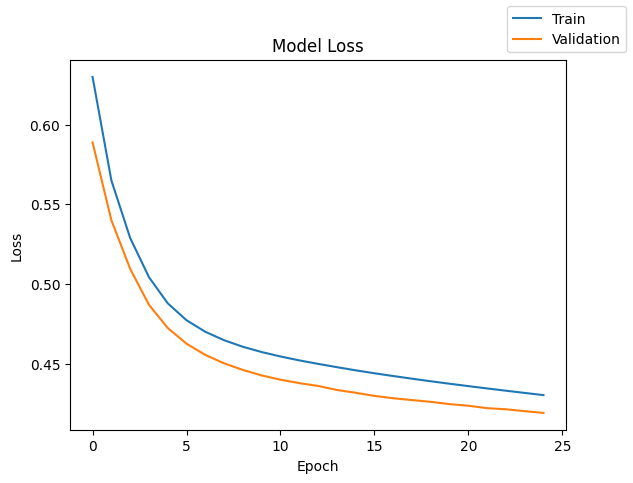

```python
plot(history, "loss")
```

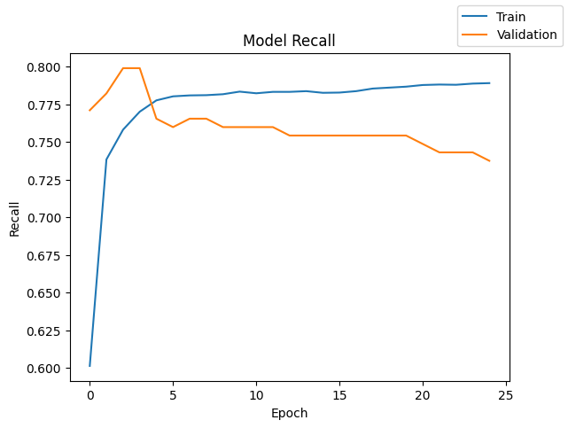

```python
plot(history,'recall')
```

```python
results.loc[3]=['2','[128,64]','[relu,relu]',epochs,batch_size,'SGD','-','Yes',(end-start),history.history["loss"][-1],history.history["val_loss"][-1],history.history["recall"][-1],history.history["val_recall"][-1]]
```

```python
results
```

|  | # hidden layers | # neurons - hidden layer | activation function - hidden layer | # epochs | batch size | optimizer | Dropout | SMOTE | time(secs) | Train_loss | Valid_loss | Train_Recall | Valid_Recall |
| --- | --- | --- | --- | --- | --- | --- | --- | --- | --- | --- | --- | --- | --- |
| 0 | 2 | [128,64] | [relu,relu] | 25 | 32 | SGD | - | - | 218.909014 | 0.343030 | 0.309187 | 0.448829 | 0.463687 |
| 1 | 2 | [128,64] | [relu,relu] | 25 | 32 | Adam | - | - | 246.185711 | 0.295605 | 0.295582 | 0.549938 | 0.541899 |
| 2 | 2 | [128,64] | [relu,relu] | 25 | 32 | Adam | [0.2,0.2] | - | 391.044503 | 0.321105 | 0.290420 | 0.495068 | 0.525140 |
| 3 | 2 | [128,64] | [relu,relu] | 25 | 32 | SGD | - | Yes | 248.838486 | 0.430218 | 0.419026 | 0.788962 | 0.737430 |

### Neural Network with Balanced Data (by applying SMOTE) and Adam Optimizer

```python
# clears the current Keras session, resetting all layers and models previously created, freeing up memory and resources.
tf.keras.backend.clear_session()
```

```python
#Initializing the neural network
model5 = Sequential()
model5.add(Dense(128,activation="relu",input_dim=x_train.shape[1]))
model5.add(Dense(64,activation="relu"))
model5.add(Dense(1,activation="sigmoid"))
```

```python
model5.summary()
```

```
Model: "sequential"
```

```
┏━━━━━━━━━━━━━━━━━━━━━━━━━━━━━━━━━━━━━━┳━━━━━━━━━━━━━━━━━━━━━━━━━━━━━┳━━━━━━━━━━━━━━━━━┓
┃ Layer (type)                         ┃ Output Shape                ┃         Param # ┃
┡━━━━━━━━━━━━━━━━━━━━━━━━━━━━━━━━━━━━━━╇━━━━━━━━━━━━━━━━━━━━━━━━━━━━━╇━━━━━━━━━━━━━━━━━┩
│ dense (Dense)                        │ (None, 128)                 │           1,536 │
├──────────────────────────────────────┼─────────────────────────────┼─────────────────┤
│ dense_1 (Dense)                      │ (None, 64)                  │           8,256 │
├──────────────────────────────────────┼─────────────────────────────┼─────────────────┤
│ dense_2 (Dense)                      │ (None, 1)                   │              65 │
└──────────────────────────────────────┴─────────────────────────────┴─────────────────┘
```

```
 Total params: 9,857 (38.50 KB)
```

```
 Trainable params: 9,857 (38.50 KB)
```

```
 Non-trainable params: 0 (0.00 B)
```

```python
optimizer = keras.optimizers.Adam()    # defining Adam as the optimizer to be used
model5.compile(loss="binary_crossentropy", optimizer=optimizer, metrics=metrics,run_eagerly=True)
```

```python
start = time.time()
history = model5.fit(x_train_over, y_train_over, validation_data=(x_val,y_val) , batch_size=batch_size, epochs=epochs)
end=time.time()
```

```
399/399 ━━━━━━━━━━━━━━━━━━━━ 15s 37ms/step - loss: 0.5536 - recall: 0.7386 - val_loss: 0.4273 - val_recall: 0.7318
399/399 ━━━━━━━━━━━━━━━━━━━━ 15s 39ms/step - loss: 0.4551 - recall: 0.7635 - val_loss: 0.4293 - val_recall: 0.7374
399/399 ━━━━━━━━━━━━━━━━━━━━ 15s 37ms/step - loss: 0.4397 - recall: 0.7694 - val_loss: 0.4267 - val_recall: 0.7318
399/399 ━━━━━━━━━━━━━━━━━━━━ 21s 39ms/step - loss: 0.4277 - recall: 0.7763 - val_loss: 0.4242 - val_recall: 0.7039
399/399 ━━━━━━━━━━━━━━━━━━━━ 20s 37ms/step - loss: 0.4166 - recall: 0.7886 - val_loss: 0.4231 - val_recall: 0.7039
399/399 ━━━━━━━━━━━━━━━━━━━━ 15s 39ms/step - loss: 0.4064 - recall: 0.7977 - val_loss: 0.4209 - val_recall: 0.7039
399/399 ━━━━━━━━━━━━━━━━━━━━ 15s 39ms/step - loss: 0.3964 - recall: 0.8018 - val_loss: 0.4227 - val_recall: 0.6872
399/399 ━━━━━━━━━━━━━━━━━━━━ 21s 39ms/step - loss: 0.3867 - recall: 0.8086 - val_loss: 0.4235 - val_recall: 0.6760
399/399 ━━━━━━━━━━━━━━━━━━━━ 20s 37ms/step - loss: 0.3772 - recall: 0.8134 - val_loss: 0.4232 - val_recall: 0.6816
399/399 ━━━━━━━━━━━━━━━━━━━━ 15s 39ms/step - loss: 0.3681 - recall: 0.8201 - val_loss: 0.4239 - val_recall: 0.6648
399/399 ━━━━━━━━━━━━━━━━━━━━ 20s 37ms/step - loss: 0.3591 - recall: 0.8262 - val_loss: 0.4264 - val_recall: 0.6648
399/399 ━━━━━━━━━━━━━━━━━━━━ 21s 37ms/step - loss: 0.3504 - recall: 0.8354 - val_loss: 0.4295 - val_recall: 0.6704
399/399 ━━━━━━━━━━━━━━━━━━━━ 21s 37ms/step - loss: 0.3418 - recall: 0.8427 - val_loss: 0.4308 - val_recall: 0.6648
399/399 ━━━━━━━━━━━━━━━━━━━━ 15s 37ms/step - loss: 0.3335 - recall: 0.8482 - val_loss: 0.4335 - val_recall: 0.6648
399/399 ━━━━━━━━━━━━━━━━━━━━ 15s 37ms/step - loss: 0.3254 - recall: 0.8532 - val_loss: 0.4356 - val_recall: 0.6536
399/399 ━━━━━━━━━━━━━━━━━━━━ 20s 37ms/step - loss: 0.3177 - recall: 0.8593 - val_loss: 0.4398 - val_recall: 0.6536
399/399 ━━━━━━━━━━━━━━━━━━━━ 20s 37ms/step - loss: 0.3105 - recall: 0.8661 - val_loss: 0.4427 - val_recall: 0.6592
399/399 ━━━━━━━━━━━━━━━━━━━━ 21s 38ms/step - loss: 0.3037 - recall: 0.8731 - val_loss: 0.4476 - val_recall: 0.6536
399/399 ━━━━━━━━━━━━━━━━━━━━ 20s 37ms/step - loss: 0.2969 - recall: 0.8773 - val_loss: 0.4505 - val_recall: 0.6480
399/399 ━━━━━━━━━━━━━━━━━━━━ 21s 38ms/step - loss: 0.2906 - recall: 0.8817 - val_loss: 0.4548 - val_recall: 0.6480
399/399 ━━━━━━━━━━━━━━━━━━━━ 15s 37ms/step - loss: 0.2841 - recall: 0.8875 - val_loss: 0.4581 - val_recall: 0.6313
399/399 ━━━━━━━━━━━━━━━━━━━━ 20s 37ms/step - loss: 0.2782 - recall: 0.8895 - val_loss: 0.4612 - val_recall: 0.6313
399/399 ━━━━━━━━━━━━━━━━━━━━ 15s 37ms/step - loss: 0.2724 - recall: 0.8936 - val_loss: 0.4654 - val_recall: 0.6313
399/399 ━━━━━━━━━━━━━━━━━━━━ 15s 38ms/step - loss: 0.2665 - recall: 0.8977 - val_loss: 0.4682 - val_recall: 0.6313
399/399 ━━━━━━━━━━━━━━━━━━━━ 15s 37ms/step - loss: 0.2613 - recall: 0.9027 - val_loss: 0.4719 - val_recall: 0.6313
```

```python
print("Time taken in seconds ",end-start)
```

```
Time taken in seconds  452.003888130188
```

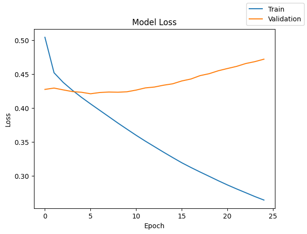

```python
plot(history, "loss")
```

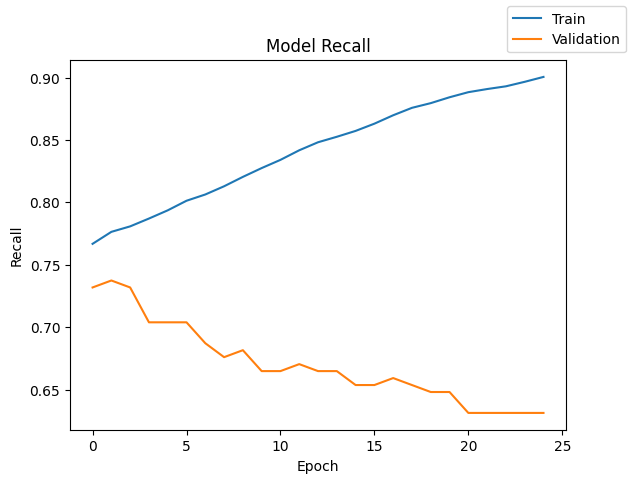

```python
plot(history,'recall')
```

```python
results.loc[4]=['2','[128,64]','[relu,relu]',epochs,batch_size,'Adam','-','Yes',(end-start),history.history["loss"][-1],history.history["val_loss"][-1],history.history["recall"][-1],history.history["val_recall"][-1]]
```

```python
results
```

|  | # hidden layers | # neurons - hidden layer | activation function - hidden layer | # epochs | batch size | optimizer | Dropout | SMOTE | time(secs) | Train_loss | Valid_loss | Train_Recall | Valid_Recall |
| --- | --- | --- | --- | --- | --- | --- | --- | --- | --- | --- | --- | --- | --- |
| 0 | 2 | [128,64] | [relu,relu] | 25 | 32 | SGD | - | - | 218.909014 | 0.343030 | 0.309187 | 0.448829 | 0.463687 |
| 1 | 2 | [128,64] | [relu,relu] | 25 | 32 | Adam | - | - | 246.185711 | 0.295605 | 0.295582 | 0.549938 | 0.541899 |
| 2 | 2 | [128,64] | [relu,relu] | 25 | 32 | Adam | [0.2,0.2] | - | 391.044503 | 0.321105 | 0.290420 | 0.495068 | 0.525140 |
| 3 | 2 | [128,64] | [relu,relu] | 25 | 32 | SGD | - | Yes | 248.838486 | 0.430218 | 0.419026 | 0.788962 | 0.737430 |
| 4 | 2 | [128,64] | [relu,relu] | 25 | 32 | Adam | - | Yes | 452.003888 | 0.264345 | 0.471866 | 0.900596 | 0.631285 |

- Applying SMOTE to balance the data resulted in a model with significantly better recall but also increased overfitting compared to the Adam model without SMOTE, and with a longer training time.
- Validation recall is lower than training recall, indicates overfitting.